# Dose REsponse models for bAyesian Model avERaging (dreamer)

Richard Payne

## dreamer

The dreamer R package provides functions to easily perform Bayesian model averaging on (longitudinal) dose-response models. It also provides functions to generate data, and some useful post-processing functions including posterior means and quantiles, plots, and other metrics (e.g. calculating the posterior probability minimum efficacious dose, etc.).

See the “dreamer_method” vignette for a high-level overview of Bayesian model averaging and/or read Gould (2019) for the approach used by dreamer.

## Generate data

We can easily see the possible models to generate data from by typing `?dreamer_data` in the console. We will start by generating data from a quadratic model.

```r
library(dreamer)
library(dplyr)
library(ggplot2)
set.seed(888)
data <- dreamer_data_quad(
  n_cohorts = c(20, 20, 20, 20, 20), # number of subjects in each cohort
  doses = c(0, .5, 1, 1.5, 2), # dose administered to each cohort
  b1 = 5, # intercept
  b2 = 5,
  b3 = - 2,
  sigma = 2 # standard deviation
)
head(data)
```

```
##   cohort dose subject response
## 1      1    0       1 1.097313
## 2      1    0       2 1.911268
## 3      1    0       3 6.459665
## 4      1    0       4 4.444836
## 5      1    0       5 1.687431
## 6      1    0       6 4.497953
```

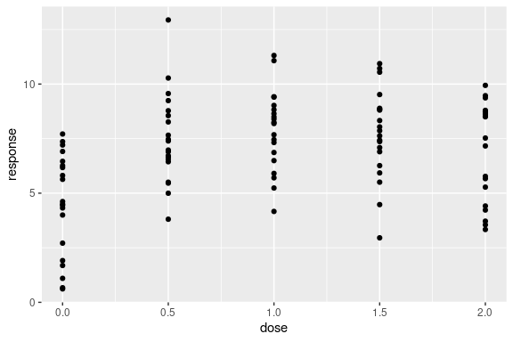

```r
ggplot(data, aes(dose, response)) + geom_point()
```

## Fit Model

Hyperparameters for each model are set by using the `model_XXX()` functions. Type `?model` for a description of the model constructors and the models each of them fit. The model functions take hyperparameters and put them in a named list:

```r
model_quad(
  mu_b1 = 0,
  sigma_b1 = 10,
  mu_b2 = 0,
  sigma_b2 = 10,
  mu_b3 = 0,
  sigma_b3 = 10,
  shape = 1,
  rate = .001,
  w_prior = 1 / 2
)
```

```
## -------------
## dreamer Model
## -------------
## type    : quadratic
## response: continuous
##
## Dose Response
## |hyperparameter | value|
## |:--------------|-----:|
## |mu_b1          | 0e+00|
## |sigma_b1       | 1e+01|
## |mu_b2          | 0e+00|
## |sigma_b2       | 1e+01|
## |mu_b3          | 0e+00|
## |sigma_b3       | 1e+01|
## |shape          | 1e+00|
## |rate           | 1e-03|
## |w_prior        | 5e-01|
```

The dreamer models are then used in the `dreamer_mcmc()` function:

```r
# Bayesian model averaging
output <- dreamer_mcmc(
  data = data,
  n_adapt = 1e3,
  n_burn = 1e3,
  n_iter = 1e4,
  n_chains = 2,
  silent = TRUE,
  # the argument name "mod_quad" is arbitrary and is chosen by the user
  mod_quad = model_quad(
    mu_b1 = 0,
    sigma_b1 = 10,
    mu_b2 = 0,
    sigma_b2 = 10,
    mu_b3 = 0,
    sigma_b3 = 10,
    shape = 1,
    rate = .001,
    w_prior = 1 / 2
  ),
  # the argument name "mod_emax" is arbitrary and is chosen by the user
  mod_emax = model_emax(
    mu_b1 = 0,
    sigma_b1 = 10,
    mu_b2 = 0,
    sigma_b2 = 10,
    mu_b3 = 0,
    sigma_b3 = 2,
    mu_b4 = 1,
    sigma_b4 = 5,
    shape = 1,
    rate = .001,
    w_prior = 1 / 2
  )
)
```

### Model Output

The output is a list of the sorted unique doses, unique times (for longitudinal models), the prior and posterior weights for each model, and MCMC output from each individual model. However, the default print method makes it easy to see high-level summaries of the model fit, including the posterior weights for each model:

```r
output
```

```
## -----------------
## dreamer Model Fit
## -----------------
## doses: 0, 0.5, 1, 1.5, 2
##
## | dose|  mean| 2.50%| 97.50%|
## |----:|-----:|-----:|------:|
## |  0.0| 4.668| 3.738|  5.569|
## |  0.5| 7.133| 6.450|  7.824|
## |  1.0| 7.844| 7.154|  8.607|
## |  1.5| 7.828| 7.183|  8.494|
## |  2.0| 7.113| 6.052|  7.974|
##
## |model    | prior weight| posterior weight|
## |:--------|------------:|----------------:|
## |mod_quad |          0.5|            0.616|
## |mod_emax |          0.5|            0.384|
```

Output can be easily summarized. The `summary()` function provides posterior estimates of parameters, Gelman diagnostics, and effective sample sizes for each model and parameter.

```r
summary(output)
```

```
## $model_weights
## # A tibble: 2 × 3
##   model    posterior_weight prior_weight
##   <chr>    <chr>            <chr>
## 1 mod_quad 61.6%            50.0%
## 2 mod_emax 38.4%            50.0%
##
## $summary
## # A tibble: 9 × 14
##   model    param  mean    sd      se   se_ts  `2.5%` `25%` `50%` `75%` `97.5%`
##   <chr>    <chr> <dbl> <dbl>   <dbl>   <dbl>   <dbl> <dbl> <dbl> <dbl>   <dbl>
## 1 mod_quad b1     4.76 0.441 0.00312 0.00312  3.89    4.47  4.76  5.06    5.62
## 2 mod_quad b2     5.53 1.05  0.00739 0.00745  3.47    4.83  5.54  6.24    7.55
## 3 mod_quad b3    -2.25 0.503 0.00356 0.00358 -3.23   -2.59 -2.25 -1.91   -1.26
## 4 mod_quad sigma  2.11 0.152 0.00107 0.00109  1.84    2.00  2.10  2.20    2.43
## 5 mod_emax b1     4.52 0.475 0.00336 0.00347  3.60    4.20  4.51  4.84    5.46
## 6 mod_emax b2     8.02 1.13  0.00799 0.0688   7.10    7.43  7.63  7.90   11.4
## 7 mod_emax b3    -1.98 1.46  0.0103  0.0556  -4.79   -2.79 -1.94 -1.29    1.77
## 8 mod_emax b4     4.39 3.43  0.0243  0.110    0.0370  1.60  3.90  6.52   12.3
## 9 mod_emax sigma  2.10 0.150 0.00106 0.00107  1.83    1.99  2.09  2.19    2.41
## # ℹ 3 more variables: gelman_point <dbl>, gelman_upper <dbl>,
## #   effective_size <dbl>
```

### Posterior Credible Intervals

It is easy to find posterior credible intervals of the mean response for doses of interest:

```r
posterior(output)
```

```
## $stats
## # A tibble: 5 × 4
##    dose  mean `2.50%` `97.50%`
##   <dbl> <dbl>   <dbl>    <dbl>
## 1   0    4.67    3.74     5.57
## 2   0.5  7.13    6.45     7.82
## 3   1    7.84    7.15     8.61
## 4   1.5  7.83    7.18     8.49
## 5   2    7.11    6.05     7.97
```

```r
# posterior Pr(effect of dose - effect of reference dose)
posterior(x = output, reference_dose = 0)
```

```
## $stats
## # A tibble: 5 × 5
##    dose reference_dose  mean `2.50%` `97.50%`
##   <dbl>          <dbl> <dbl>   <dbl>    <dbl>
## 1   0                0  0       0        0
## 2   0.5              0  2.47    1.47     3.72
## 3   1                0  3.18    2.06     4.32
## 4   1.5              0  3.16    2.05     4.29
## 5   2                0  2.44    1.06     3.87
```

## Posterior Plots

Plot the Bayesian model averaging posterior over the dose range:

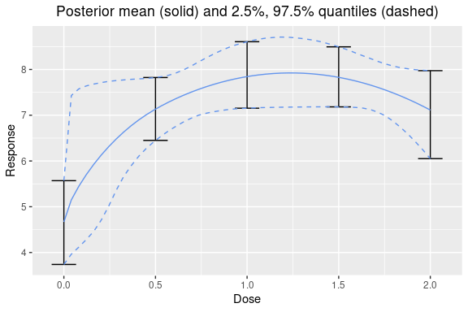

```r
plot(output)
```

One can also plot the observed means on top of the plot:

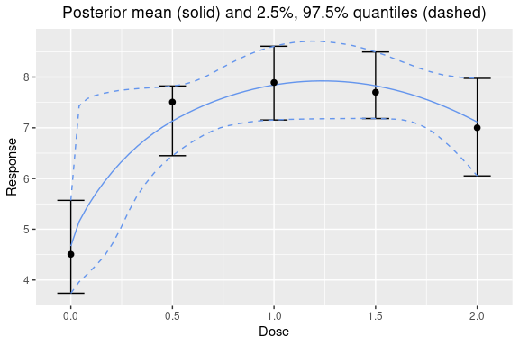

```r
plot(output, data = data)
```

One can also look the dose response relative to a specific dose:

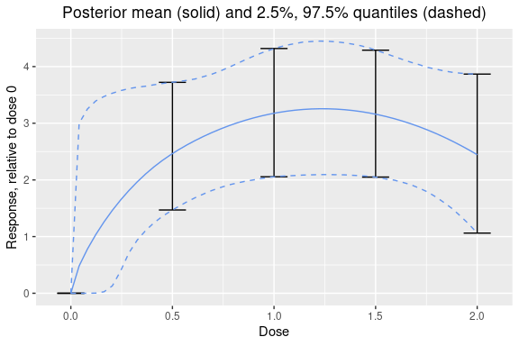

```r
plot(output, reference_dose = 0) # adjust relative to dose = 0
```

The predictive credible intervals for the mean with `predictive` number of observations can be added easily:

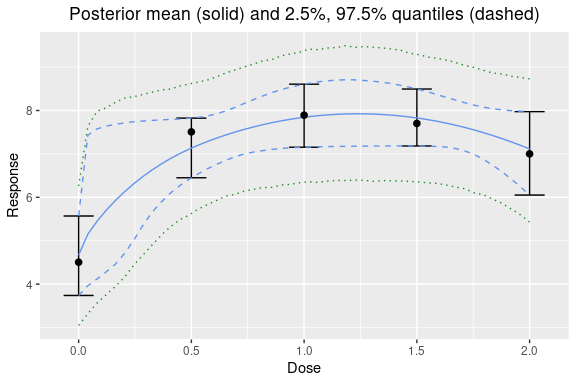

```r
plot(output, data = data, predictive = 10)
```

One could also look at the predictive distribution of the difference between two sample means from different doses:

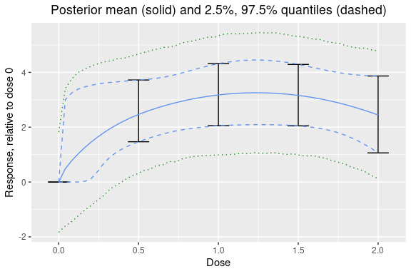

```r
plot(output, reference_dose = 0, predictive = 10)
```

One can also plot individual model fits, if desired. Here is the EMAX model’s posterior:

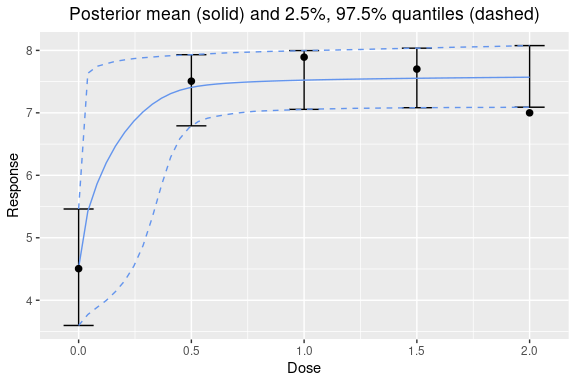

```r
plot(output$mod_emax, data = data)
```

Comparing all the model fits together is easy:

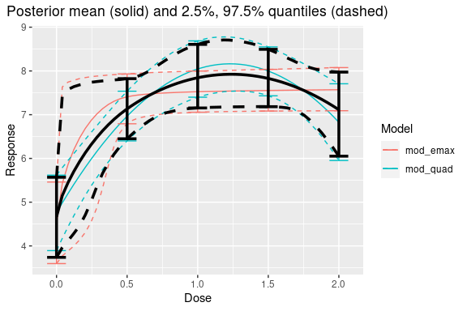

```r
plot_comparison(output)
```

If the plot is too crowded, you can select individual fits:

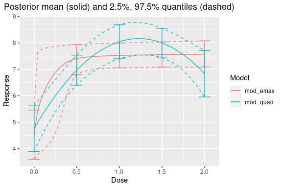

```r
plot_comparison(
  mod_emax = output$mod_emax,
  mod_quad = output$mod_quad
)
```

## Posterior Quantities

### Probability of Meeting Effect of Interest (EOI)

The posterior probability of meeting a certain effect of interest can be calculated, i.e., Pr(mean response > EOI | data). One can specify custom doses and EOIs relative to another dose, or in absolute terms.

```r
# absolute: pr(mean at dose 0.50 > 1 | data)
pr_eoi(output, eoi = 1, dose = 0.50)
```

```
## # A tibble: 1 × 3
##     eoi  dose  prob
##   <dbl> <dbl> <dbl>
## 1     1   0.5     1
```

```r
# relative: pr( (mean at dose 0.50) - (mean at dose 0.25) > 0.55 | data )
pr_eoi(output, eoi = 0.55, dose = 0.50, reference_dose = 0.25)
```

```
## # A tibble: 1 × 4
##     eoi  dose reference_dose  prob
##   <dbl> <dbl>          <dbl> <dbl>
## 1  0.55   0.5           0.25 0.720
```

```r
# vectorized
n_doses <- length(output$doses)
pr_eoi(
  output,
  eoi = rep(.55, n_doses),
  dose = output$doses,
  reference_dose = rep(0, n_doses)
)
```

```
## # A tibble: 5 × 4
##     eoi  dose reference_dose  prob
##   <dbl> <dbl>          <dbl> <dbl>
## 1  0.55   0                0 0
## 2  0.55   0.5              0 1.00
## 3  0.55   1                0 1
## 4  0.55   1.5              0 1
## 5  0.55   2                0 0.997
```

Posterior probabilities of meeting the effect of interest can be calculated for individual models by applying the `pr_eoi()` function to a specific model’s output:

```r
# from the quadratic model
pr_eoi(
  output$mod_quad,
  eoi = 1.5,
  dose = .75,
  reference_dose = 0
)
```

```
## # A tibble: 1 × 4
##     eoi  dose reference_dose  prob
##   <dbl> <dbl>          <dbl> <dbl>
## 1   1.5  0.75              0 0.995
```

### Probability of Minimum Efficacious Dose (MED)

Calculating the probability each dose is the minimum efficacious dose (as defined as the smallest dose which is above a certain clinically significant difference (CSD)) in the set of doses is performed with the `pr_med()` function:

```r
pr_med(output, csd = 8)
```

```
## # A tibble: 5 × 2
##    dose    prob
##   <dbl>   <dbl>
## 1   0   0
## 2   0.5 0.0051
## 3   1   0.347
## 4   1.5 0.0506
## 5   2   0.00525
```

```r
# placebo adjusted
pr_med(
  output,
  csd = 3,
  reference_dose = 0
)
```

```
## # A tibble: 5 × 3
##    dose reference_dose    prob
##   <dbl>          <dbl>   <dbl>
## 1   0                0 0
## 2   0.5              0 0.175
## 3   1                0 0.445
## 4   1.5              0 0.0296
## 5   2                0 0.00435
```

```r
# relative to placebo grp (dose = 0) for just the EMAX model
pr_med(
  output$mod_emax,
  csd = 3,
  reference_dose = 0
)
```

```
## # A tibble: 5 × 3
##    dose reference_dose   prob
##   <dbl>          <dbl>  <dbl>
## 1   0                0 0
## 2   0.5              0 0.423
## 3   1                0 0.0849
## 4   1.5              0 0.0217
## 5   2                0 0.0122
```

### Probability of Minimum Dose with at Least X% Efficacy

Calculating the posterior probability each of the specified doses is the smallest dose with at least X% efficacy can be done as follows:

```r
# looking for smallest dose with 95% of the maximum efficacy
pr_medx(output, ed = 95)
```

```
## # A tibble: 5 × 3
##      ed dose     prob
##   <dbl> <chr>   <dbl>
## 1    95 0     0
## 2    95 0.5   0.322
## 3    95 1     0.665
## 4    95 1.5   0.0138
## 5    95 2     0.00015
```

These functions obtain posterior quantiles of the minimum efficacious dose which has X% of maximum efficacy.

```r
post_medx(output, ed = 95)
```

```
## $stats
##   ed pr_edx_exists      mean       2.5%     97.5%
## 1 95             1 0.6075771 0.01855687 0.9584038
```

### Posterior Distribution of Percentage Effect

This function provides the posterior quantiles of a dose’s effective dose percent. This is calculated by calculating the dose’s response divided by the maximum response over the range for each iteration of the MCMC.

```r
post_perc_effect(
  output,
  dose = c(.05, .5)
)
```

```
## $stats
## # A tibble: 2 × 5
##    dose pr_perc_exists  mean `2.50%` `97.50%`
##   <dbl>          <dbl> <dbl>   <dbl>    <dbl>
## 1  0.05              1 0.660   0.505    0.995
## 2  0.5               1 0.900   0.803    1.00
```

## MCMC Diagnostics

Get diagnostics for each parameter:

```r
diagnostics(output)
```

```
## # A tibble: 9 × 5
##   model    param gelman_point gelman_upper effective_size
##   <chr>    <chr>        <dbl>        <dbl>          <dbl>
## 1 mod_quad b1            1.00         1.00         20000.
## 2 mod_quad b2            1.00         1.00         19706.
## 3 mod_quad b3            1.00         1.00         19685.
## 4 mod_quad sigma         1.00         1.00         19343.
## 5 mod_emax b1            1.00         1.00         18816.
## 6 mod_emax b2            1.02         1.05           267.
## 7 mod_emax b3            1.01         1.02           710.
## 8 mod_emax b4            1.00         1.01          1010.
## 9 mod_emax sigma         1.00         1.00         19754.
```

```r
# single model
diagnostics(output$mod_emax)
```

```
## # A tibble: 5 × 4
##   param gelman_point gelman_upper effective_size
##   <chr>        <dbl>        <dbl>          <dbl>
## 1 b1            1.00         1.00         18816.
## 2 b2            1.02         1.05           267.
## 3 b3            1.01         1.02           710.
## 4 b4            1.00         1.01          1010.
## 5 sigma         1.00         1.00         19754.
```

MCMC traceplots are easy to plot:

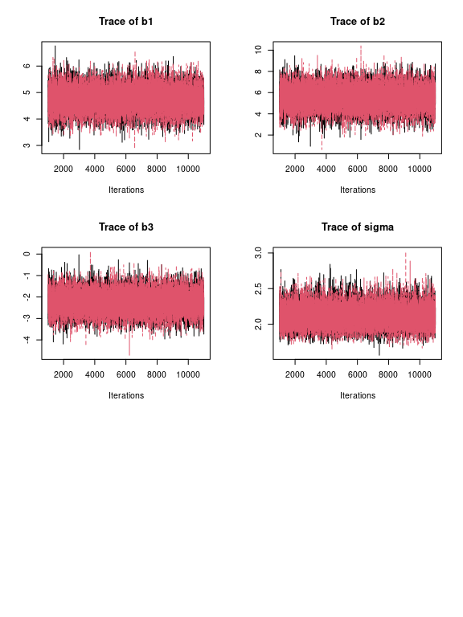

```r
# single model
plot_trace(output$mod_quad)
```

```r
# traceplot for all parameters for each model using: plot_trace(output)
```

## Visualizing Priors

To help users choose a prior, the `dreamer_plot_prior()` function allows the user to see what the prior actually looks like in context of the dose range for a particular model. This is particularly helpful for complex models, or binary models.

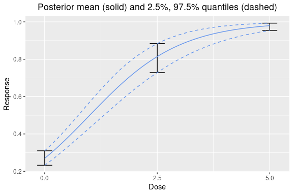

```r
dreamer_plot_prior(
  doses = c(0, 2.5, 5),
  mod_linear_binary = model_linear_binary(
    mu_b1 = - 1,
    sigma_b1 = .1,
    mu_b2 = 1,
    sigma_b2 = .1,
    link = "logit",
    w_prior = 1
  )
)
```

Individual prior draws can also be plotted:

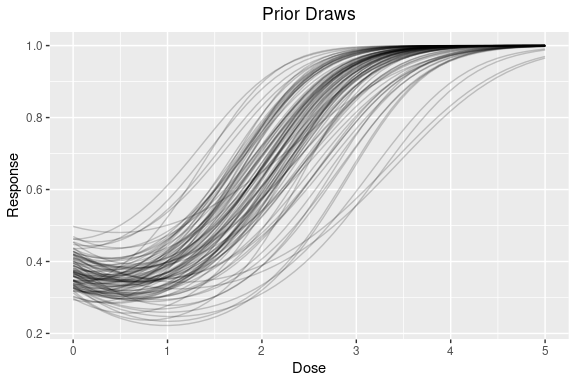

```r
dreamer_plot_prior(
  doses = seq(from = 0, to = 5, length.out = 50),
  n_samples = 100,
  plot_draws = TRUE,
  mod_quad_binary = model_quad_binary(
    mu_b1 = - .5,
    sigma_b1 = .2,
    mu_b2 = - .5,
    sigma_b2 = .2,
    mu_b3 = .5,
    sigma_b3 = .1,
    link = "logit",
    w_prior = 1
  )
)
```

One can also view the prior for all the models combined in a Bayesian model averaging prior!

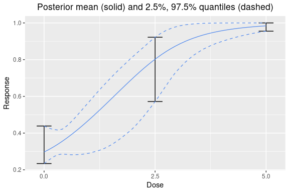

```r
dreamer_plot_prior(
  doses = c(0, 2.5, 5),
  mod_linear_binary = model_linear_binary(
    mu_b1 = - 1,
    sigma_b1 = .1,
    mu_b2 = 1,
    sigma_b2 = .1,
    link = "logit",
    w_prior = .75
  ),
  mod_quad_binary = model_quad_binary(
    mu_b1 = - .5,
    sigma_b1 = .2,
    mu_b2 = - .5,
    sigma_b2 = .2,
    mu_b3 = .5,
    sigma_b3 = .1,
    link = "logit",
    w_prior = .25
  )
)
```

## Independent Model

An independent mean model can also be fit to each of the doses. In this case, because no parametric assumptions are made on the dose-response curve, no Bayesian model averaging is employed and no interpolation is allowed.

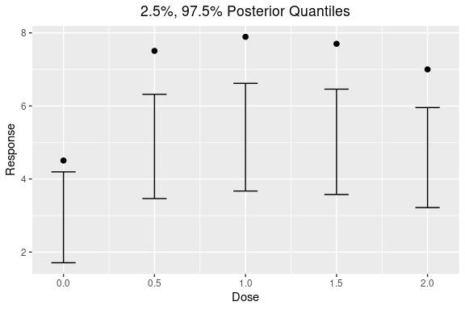

```r
output_independent <- dreamer_mcmc(
  data = data,
  n_adapt = 1e3,
  n_burn = 1e3,
  n_iter = 1e4,
  n_chains = 2,
  silent = TRUE, # make rjags be quiet,
  # this model has the same prior on the mean for each dose
  mod_indep = model_independent(
    mu_b1 = 0,
    sigma_b1 = 1,
    shape = 1,
    rate = .001
  )
)
# prior is too strong!
plot(output_independent, data = data)
```

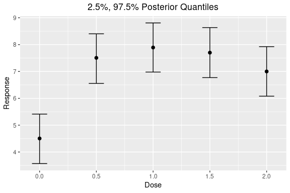

```r
output_independent2 <- dreamer_mcmc(
  data = data,
  n_adapt = 1e3,
  n_burn = 1e3,
  n_iter = 1e4,
  n_chains = 2,
  silent = TRUE, # make rjags be quiet,
  # this model has the different priors on the mean for each dose
  mod_indep = model_independent(
    mu_b1 = c(0, 1, 2, 3, 4),
    sigma_b1 = c(10, 10, 20, 20, 30),
    shape = 1,
    rate = .001,
    doses = c(0, 0.5, 1, 1.5, 2)
  )
)
plot(output_independent2, data = data)
```

All other functions are also available on independent models as above.

## Longitudinal Modeling

Longitudinal modeling is also available in `dreamer`. Longitudinal data can be generated by specifying the `longitudinal` argument, the longitudinal parameters, and the times to observe subjects. See documentation for `dreamer::model_longitudinal()` and `dreamer::model` for the parameterization of the longitudinal models.

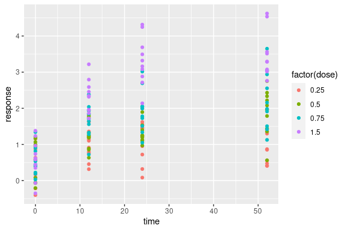

```r
set.seed(889)
data_long <- dreamer_data_linear(
  n_cohorts = c(10, 10, 10, 10), # number of subjects in each cohort
  doses = c(.25, .5, .75, 1.5), # dose administered to each cohort
  b1 = 0, # intercept
  b2 = 2, # slope
  sigma = .5, # standard deviation,
  longitudinal = "itp",
  times = c(0, 12, 24, 52),
  t_max = 52, # maximum time
  a = .5,
  c1 = .1
)

ggplot(data_long, aes(time, response, group = dose, color = factor(dose))) +
  geom_point()
```

Fitting the MCMC is the same as before, except priors need to be specified for the longitudinal part of the model:

```r
# Bayesian model averaging
output_long <- dreamer_mcmc(
  data = data_long,
  n_adapt = 1e3,
  n_burn = 1e3,
  n_iter = 1e4,
  n_chains = 2,
  silent = TRUE, # make rjags be quiet,
  mod_linear = model_linear(
    mu_b1 = 0,
    sigma_b1 = 1,
    mu_b2 = 0,
    sigma_b2 = 1,
    shape = 1,
    rate = .001,
    w_prior = 1 / 2, # prior probability of the model
    longitudinal = model_longitudinal_itp(
      mu_a = 0,
      sigma_a = 1,
      a_c1 = 0,
      b_c1 = 1,
      t_max = 52
    )
  ),
  mod_quad = model_quad(
    mu_b1 = 0,
    sigma_b1 = 1,
    mu_b2 = 0,
    sigma_b2 = 1,
    mu_b3 = 0,
    sigma_b3 = 1,
    shape = 1,
    rate = .001,
    w_prior = 1 / 2,
    longitudinal = model_longitudinal_linear(
      mu_a = 0,
      sigma_a = 1,
      t_max = 52
    )
  )
)
```

Plotting longitudinal models is straightforward:

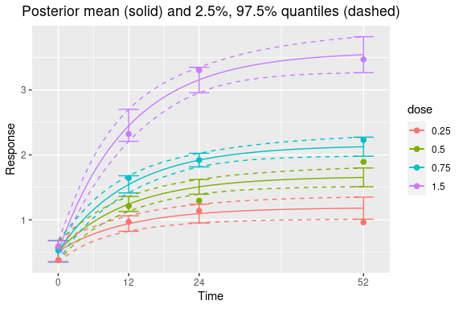

```r
plot(output_long, data = data_long)
```

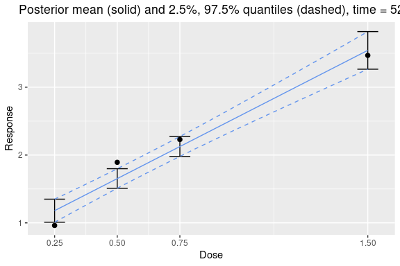

```r
# plot dose response at last time point
plot(output_long, times = 52, data = data_long)
```

All the other posterior quantity functions work on longitudinal data. For example:

```r
posterior(output_long)
```

```
## $stats
## # A tibble: 16 × 5
##     dose  time  mean `2.50%` `97.50%`
##    <dbl> <dbl> <dbl>   <dbl>    <dbl>
##  1  0.25     0 0.516   0.352    0.678
##  2  0.25    12 0.941   0.824    1.06
##  3  0.25    24 1.10    0.951    1.24
##  4  0.25    52 1.18    1.01     1.35
##  5  0.5      0 0.516   0.352    0.678
##  6  0.5     12 1.24    1.13     1.36
##  7  0.5     24 1.51    1.39     1.62
##  8  0.5     52 1.65    1.51     1.80
##  9  0.75     0 0.516   0.352    0.678
## 10  0.75    12 1.54    1.41     1.68
## 11  0.75    24 1.92    1.82     2.02
## 12  0.75    52 2.13    1.98     2.27
## 13  1.5      0 0.516   0.352    0.678
## 14  1.5     12 2.45    2.21     2.70
## 15  1.5     24 3.16    2.96     3.35
## 16  1.5     52 3.54    3.27     3.82
```

## Reference

Gould, A. Lawrence. “BMA‐Mod: A Bayesian model averaging strategy for determining dose‐response relationships in the presence of model uncertainty.” *Biometrical Journal* 61.5 (2019): 1141-1159.